# act_report

## Data Overview

The dataset contains 2356 information on dog ratings including the tweet id, dog types, dog names and dog ratings.I scraped additional data on the dog retweets from twitter using twitter API. This data contained information on the count of retweets and favourite counts of the dogs. In addition to these I also programmatically downloaded data on images predictions using python's request library. This data contained information on the top three image prediction of each dog rated.

## Data Wrangling

I started the data wrangling by removing columns that I did not in the analysis which includes columns in_reply_to_status_id,in_reply_to_user_id, and source.  
I also removed data on tweets that were after 1st of August 2017 as image predictions were not available for them.  
I corrected wrong data types and dropped null values. Some tweets had wrong ratings while some had no ratings at all. I used filtering and visual assessment to find all these tweets and then corrected them programmatically.  
I also discovered some names inputed for dog names were wrong. The dog names were gotten from the text column and most of them had no names so 'none' was input instead. Due to this reason I dropped the dog name column.  
The dog predictions for some tweets were false and further investigation showed that these tweets did not contain dogs but infact contain other animals or objects. I dropped any tweet that contained False predictions

## Insights

1.Dog tweet id '744234799360020481' has the highest number of retweet with a retweet count of 70474. It also as the most favorite dog with a favorite count of 144487. The dog is a labrador retriever

2.The most rated dog is a dog called Atticus with a whooping rating of 1776/10. It has 2272 total retweets and has a favorite count of 4772

3.The golden retriever is the most common dog breed with a total count of over 140 dogs

## Visualization

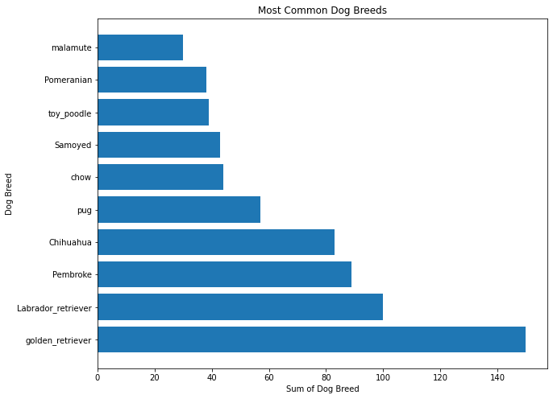